# Seminar1

Kash

11/10/2021

### Primer on the pipe operator

Create a varaible `xx` consisting of 10 uniform random varaibles. Compute the logarithm of `xx`, return suitably lagged and iterated difference, then compute the exponential function and round the result. Do this with nested functions and with the pipe operator.

```r
library(magrittr)

xx <- runif(10)

xx_no_pipes <- round(exp(diff(log(xx))),1)

xx_with_pipes <- xx %>% log() %>%
  diff() %>%
  exp() %>%
  round(1)

xx_no_pipes
```

```
## [1] 1.0 1.2 1.0 0.3 0.3 0.8 7.3 1.6 1.1
```

```r
xx_with_pipes
```

```
## [1] 1.0 1.2 1.0 0.3 0.3 0.8 7.3 1.6 1.1
```

Note the pipe operator allways passes the object to the **first** argument of the function to the right of the pipe operator. Try to understand why the following code breaks:

```r
# foo <- function(x = 5, y) return(x+y)

# xx <- 10

# xx %>% foo()
```

## Repeating the gapminder analysis

Let’s start easy by just repeating some steps but with data from a different year.

### Create the `gapminder` scatterplot using data from the year 2002

```r
library(gapminder)
library(tidyverse)
```

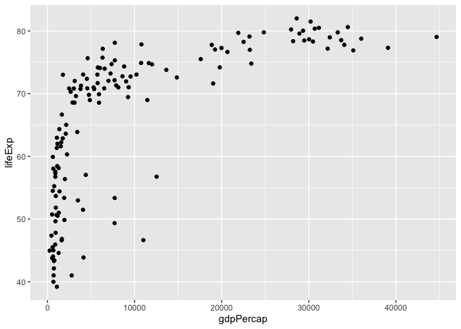

```r
gapm_2002 <- gapminder %>%
  filter(year == 2002)

gapm_2002_scatter <- ggplot(gapm_2002,
                            aes(x = gdpPercap, y = lifeExp)) +
  geom_point()

gapm_2002_scatter
```

#### Create an lm model to predict lifeExp

That is find the fitted values $\hat{Y} = X \hat{\beta}$, where:

$$\hat{\beta} = (X'X)^{-1}X'Y$$

```r
library(broom)

lm_2002 <- lm(lifeExp ~ gdpPercap, data = gapm_2002)
lm_2002_predictions <- augment(lm_2002)

glance(lm_2002)
```

```
## # A tibble: 1 × 12
##   r.squared adj.r.squared sigma statistic  p.value    df logLik   AIC   BIC
##       <dbl>         <dbl> <dbl>     <dbl>    <dbl> <dbl>  <dbl> <dbl> <dbl>
## 1     0.465         0.461  9.01      122. 9.54e-21     1  -513. 1031. 1040.
## # … with 3 more variables: deviance <dbl>, df.residual <int>, nobs <int>
```

#### Create a loess model to predict lifeExp

```r
loess_2002 <- loess(lifeExp ~ gdpPercap, data = gapm_2002)
loess_2002_predictions <- augment(loess_2002)

summary(loess_2002)
```

```
## Call:
## loess(formula = lifeExp ~ gdpPercap, data = gapm_2002)
##
## Number of Observations: 142
## Equivalent Number of Parameters: 4.89
## Residual Standard Error: 6.866
## Trace of smoother matrix: 5.35  (exact)
##
## Control settings:
##   span     :  0.75
##   degree   :  2
##   family   :  gaussian
##   surface  :  interpolate      cell = 0.2
##   normalize:  TRUE
##  parametric:  FALSE
## drop.square:  FALSE
```

#### Make a plot showing the two model fits

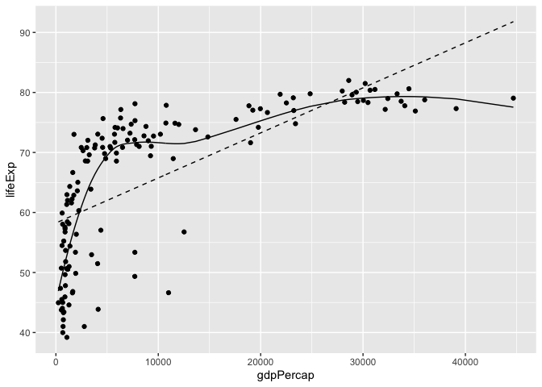

```r
gapm_2002_scatter +
  geom_line(data = lm_2002_predictions,
            aes(y = .fitted),
            linetype = "dashed") +
  geom_line(data = loess_2002_predictions,
            aes(y = .fitted))
```

#### Now calculate the MSE for the two models

```r
mean(lm_2002$residuals ** 2 )
```

```
## [1] 80.11716
```

```r
mean(loess_2002$residuals ** 2)
```

```
## [1] 45.21583
```

## Predicting on new data

Models are supposed to capture/use structure in the data that corresponds to structure in the real world. And if the real world isn’t misbehaving, that structure should be somewhat stable.

For example, suppose the relationship changed dramatically from one time period to another time period. Then it would be less useful/interesting to have a model fit on data at one time period, because the same model might have a poor fit on data from a different time period.

Let’s explore this with our `gapminder` models

#### Predictions on different years (1997 and 2007)

Create datasets for the desired years

```r
gapm_1997 <- gapminder %>%  filter(year == 1997)
gapm_2007 <- gapminder %>%  filter(year == 2007)
```

Predict using `newdata` argument, then `pull` the residuals from the resulting data.frame

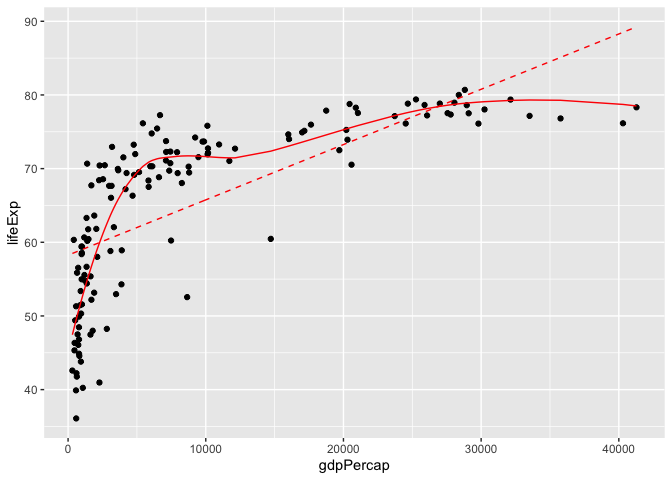

```r
lm_1997_predictions <- augment(lm_2002, newdata = gapm_1997)
loess_1997_predictions <- augment(loess_2002, newdata = gapm_1997)

ggplot(gapm_1997,
       aes(x = gdpPercap, y = lifeExp)) +
  geom_point() +
  geom_line(data = lm_1997_predictions,
            aes(y = .fitted),
            color = "red",
            linetype = "dashed") +
  geom_line(data = loess_1997_predictions,
            aes(y = .fitted),
            color = "red")
```

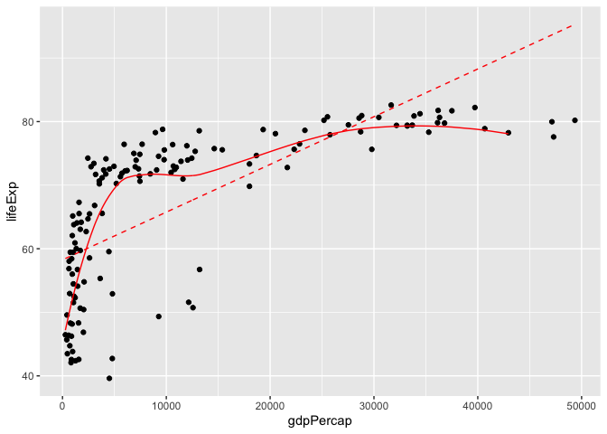

```r
lm_2007_predictions <- augment(lm_2002, newdata = gapm_2007)
loess_2007_predictions <- augment(loess_2002, newdata = gapm_2007)

ggplot(gapm_2007,
       aes(x = gdpPercap, y = lifeExp)) +
  geom_point() +
  geom_line(data = lm_2007_predictions,
            aes(y = .fitted),
            color = "red",
            linetype = "dashed") +
  geom_line(data = loess_2007_predictions,
            aes(y = .fitted),
            color = "red")
```

```r
lm_2007_resids <- lm_2007_predictions %>% pull(.resid)
loess_2007_resids <- loess_2007_predictions %>% pull(.resid)

lm_1997_resids <- lm_1997_predictions %>% pull(.resid)
loess_1997_resids <- loess_1997_predictions %>% pull(.resid)
```

```r
mean(lm_1997_predictions$residuals **2)
```

```
## [1] NaN
```

```r
mean(loess_1997_predictions$resideuals **2)
```

```
## [1] NaN
```

```r
mean(lm_2007_predictions$residuals **2)
```

```
## [1] NaN
```

```r
mean(loess_2007_predictions$resideuals **2, na.rm = TRUE)
```

```
## [1] NaN
```

#### Check the predictions on 1997

```r
mean(lm_1997_resids**2)
```

```
## [1] 67.23804
```

```r
mean(loess_1997_resids**2, na.rm = TRUE)
```

```
## [1] 31.56738
```

#### Check the predictions on 2007

```r
mean(lm_2007_resids**2)
```

```
## [1] 80.1876
```

```r
mean(loess_2007_resids**2, na.rm = TRUE)
```

```
## [1] 49.54716
```

One trade-off we see here: the `loess` function does not have any default way of extrapolating to observations outside the range of the original data (values of `gdpPercap` in 2007 that are larger than the maximum in 2002).

## Conclusion/notes

The more complex, `loess` model performs better than the linear model even when tested on data from 5 years earlier or later. Sometimes a more complex model really is better!

## Extra (if time permits)

#### Can we break the loess model by changing the span?

```r
loess_2002_badspan <- loess(lifeExp ~ gdpPercap, data = gapm_2002, span = .1)
loess_2002_badspan_predictions <- augment(loess_2002_badspan)

loess_1997_badspan_predictions <- augment(loess_2002_badspan, newdata = gapm_1997)
loess_2007_badspan_predictions <- augment(loess_2002_badspan, newdata = gapm_2007)
```

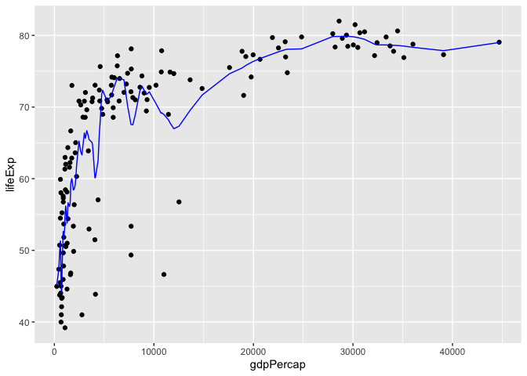

```r
gapm_2002_scatter +
  geom_line(data = loess_2002_badspan_predictions,
            aes(y = .fitted),
            color = "blue")
```

```r
mean(loess_1997_badspan_predictions$.resid ** 2)
```

```
## [1] 33.93224
```

```r
mean(lm_1997_predictions$.resid ** 2)
```

```
## [1] 67.23804
```

```r
mean(loess_2007_badspan_predictions$.resid ** 2, na.rm = TRUE)
```

```
## [1] 51.6983
```

```r
mean(lm_2007_predictions$.resid ** 2)
```

```
## [1] 80.1876
```

#### Can we change the linear model so it performs better?

```r
gapm_2002_log <- gapminder %>%
  filter(year == 2002) %>%
  mutate(log_gdpPercap = log(gdpPercap))

gapm_2007_log <- gapminder %>% filter(year == 2007) %>%
  mutate(log_gdpPercap = log10(gdpPercap))
gapm_1997_log <- gapminder %>% filter(year == 1997) %>%
  mutate(log_gdpPercap = log10(gdpPercap))
```

```r
lm_2002_log <- lm(lifeExp ~ log_gdpPercap, data = gapm_2002_log)
lm_2002_log_predictions <- augment(lm_2002_log)
```

```r
mean(augment(lm_2002, newdata = gapm_1997_log)$.resid **2)
```

```
## [1] 67.23804
```

```r
mean(loess_1997_predictions$.resid ** 2)
```

```
## [1] 31.56738
```

```r
mean(augment(lm_2002, newdata = gapm_2007_log)$.resid **2)
```

```
## [1] 80.1876
```

```r
mean(loess_1997_predictions$.resid ** 2)
```

```
## [1] 31.56738
```